# Tugas 5

Kamilah Nurul Azizah

2023-10-02

## Library

```r
library(ggplot2)
library(tsibble)
library(tseries)
library(MASS)
```

## Import Data

```r
library(rio)
data <- import("https://raw.githubusercontent.com/kamilahnrl/mpdw/main/Data/data.xlsx")
str(data)
```

```
## 'data.frame':    295 obs. of  2 variables:
##  $ No         : num  1 2 3 4 5 6 7 8 9 10 ...
##  $ BawangMerah: num  19300 18300 18000 18350 18500 ...
```

## Data Penuh

### Plot *Time Series*

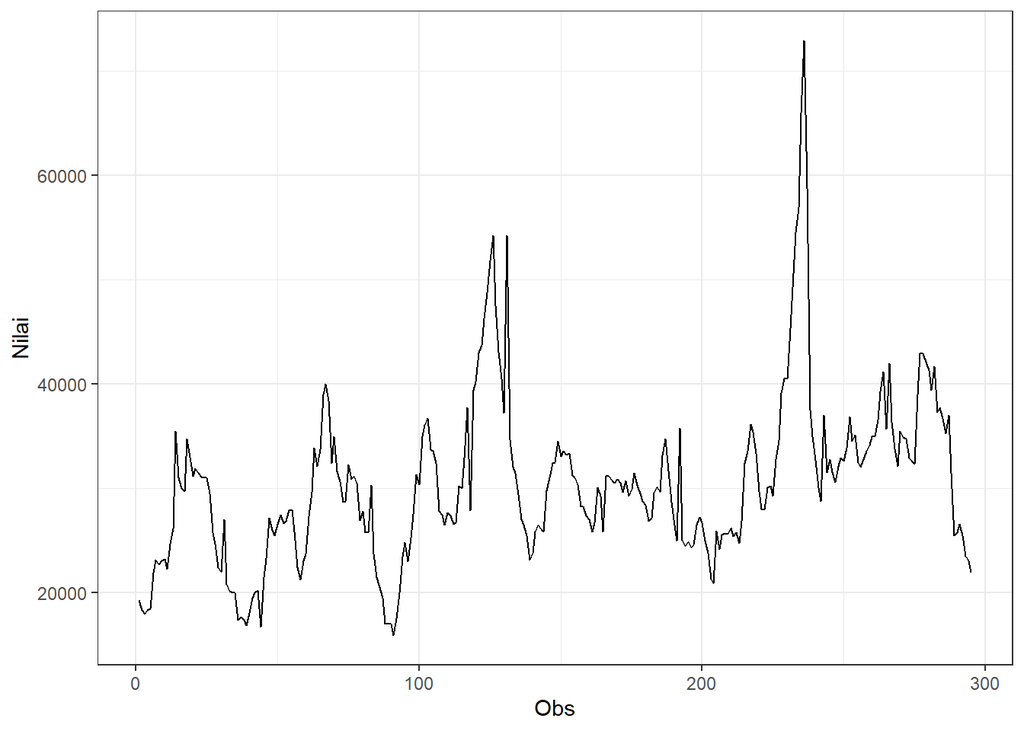

```r
data.ts <- ts(data$BawangMerah)
plot <- data.ts |> as_tsibble() |>
  ggplot(aes(x = data$No, y = data$BawangMerah)) + geom_line() + theme_bw() +
  xlab("Obs") + ylab("Nilai")
plot
```

```r
mean(data$BawangMerah)
```

```
## [1] 30426.1
```

Plot deret waktu di atas menunjukkan bahwa data stasioner dalam rataan, ditandai dengan data yang menyebar di sekitar nilai tengahnya (30426.1) dan tidak stasioner dalam ragam, ditandai dengan lebar pita yang berbeda.

### Plot ACF

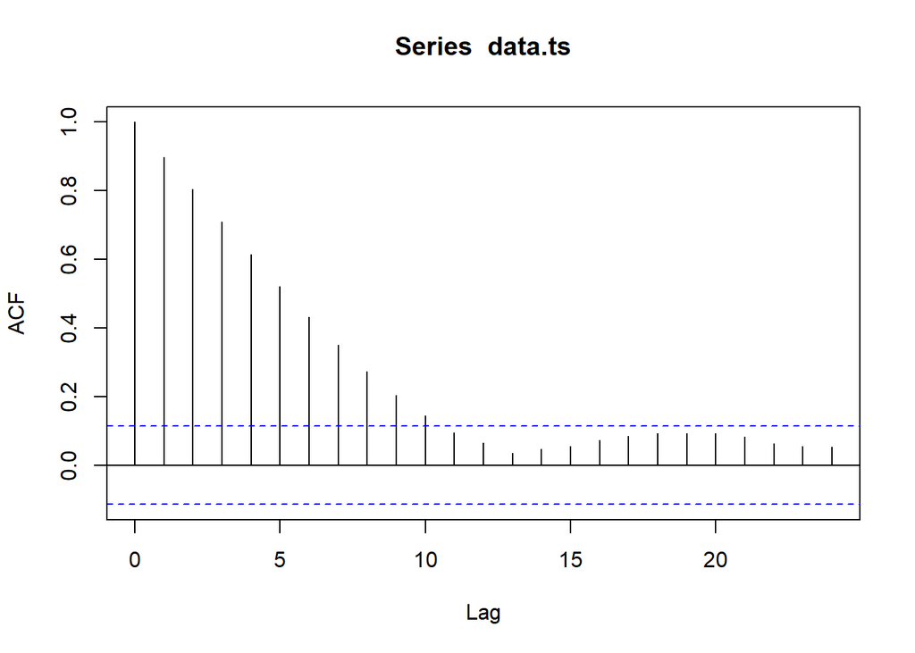

```r
acf(data.ts)
```

Berdasarkan plot ACF, terlihat bahwa plot ACF pada data tersebut *tails off* atau turun secara lambat. Hal ini memungkinkan bahwa data tidak stasioner.

### Uji ADF

```r
tseries::adf.test(data.ts)
```

```
##
##  Augmented Dickey-Fuller Test
##
## data:  data.ts
## Dickey-Fuller = -4.4498, Lag order = 6, p-value = 0.01
## alternative hypothesis: stationary
```

$H_0$ : Data tidak stasioner dalam rataan

$H_1$ : Data stasioner dalam rataan

Berdasarkan uji ADF tersebut, didapat *p-value* sebesar 0.01 yang lebih kecil dari taraf nyata 5% sehingga tolak $H_0$ dan menandakan bahwa data stasioner dalam rataan.

### Plot Box-Cox

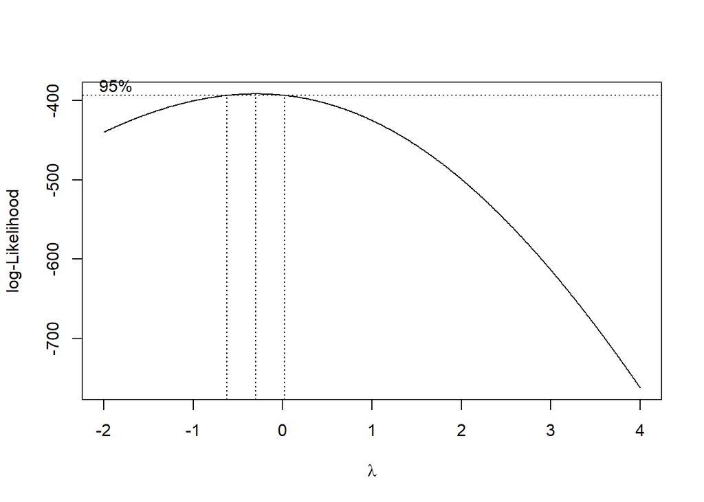

```r
index <- seq(1:295)
bc = boxcox(data.ts~index, lambda = seq(-2,4,by=0.01))
```

```r
#Nilai Rounded Lambda
lambda <- bc$x[which.max(bc$y)]
lambda
```

```
## [1] -0.3
```

```r
#SK
bc$x[bc$y > max(bc$y) - 1/2 * qchisq(.95,1)]
```

```
##  [1] -0.62 -0.61 -0.60 -0.59 -0.58 -0.57 -0.56 -0.55 -0.54 -0.53 -0.52 -0.51
## [13] -0.50 -0.49 -0.48 -0.47 -0.46 -0.45 -0.44 -0.43 -0.42 -0.41 -0.40 -0.39
## [25] -0.38 -0.37 -0.36 -0.35 -0.34 -0.33 -0.32 -0.31 -0.30 -0.29 -0.28 -0.27
## [37] -0.26 -0.25 -0.24 -0.23 -0.22 -0.21 -0.20 -0.19 -0.18 -0.17 -0.16 -0.15
## [49] -0.14 -0.13 -0.12 -0.11 -0.10 -0.09 -0.08 -0.07 -0.06 -0.05 -0.04 -0.03
## [61] -0.02 -0.01  0.00  0.01
```

Gambar di atas menunjukkan nilai *rounded value* ($\lambda$) optimum sebesar **-0.3** dan pada selang kepercayaan 95% nilai memiliki batas bawah **-0.62** dan batas atas **0.01**. Selang tersebut tidak memuat nilai 1 sehingga dapat dikatakan bahwa data tidak stasioner dalam ragam.

Dengan demikian, data stasioner dalam rataan tetapi tidak stasioner dalam ragam.

## Data Partisi 1

```r
data1 <- data.ts[1:90] |> ts()
mean(data1)
```

```
## [1] 25772.22
```

```r
var(data1)
```

```
## [1] 33387366
```

### Plot Time Series

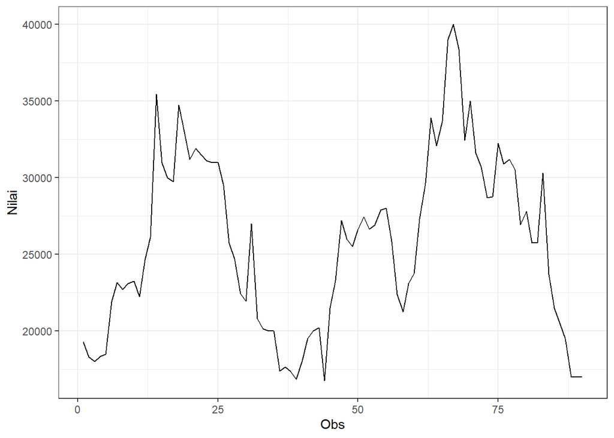

```r
data1 |> as_tsibble() |>
  ggplot(aes(x = index, y = value)) +
  geom_line() + theme_bw() +
  xlab("Obs") + ylab("Nilai")
```

Plot deret waktu di atas menunjukkan bahwa data tidak stasioner dalam rataan, ditandai dengan data yang tidak menyebar di sekitar nilai tengahnya (25772.22) dan stasioner dalam ragam, ditandai dengan lebar pita yang cenderung sama.

### Plot ACF

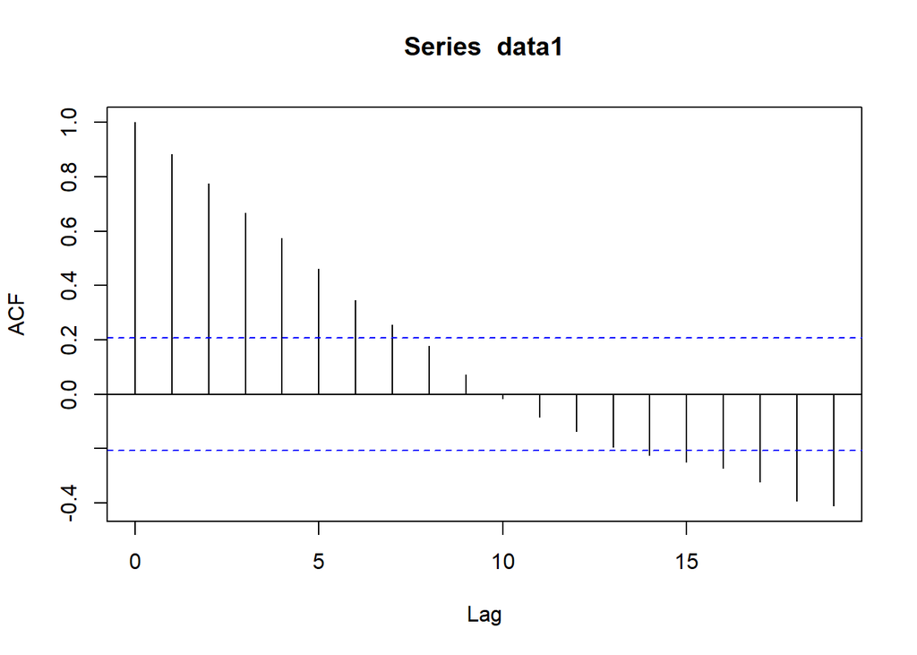

```r
acf(data1)
```

Berdasarkan plot ACF, terlihat bahwa plot ACF pada data tersebut *tails off* atau turun secara lambat. Hal ini memungkinkan bahwa data tidak stasioner.

### Uji ADF

```r
tseries::adf.test(data1)
```

```
##
##  Augmented Dickey-Fuller Test
##
## data:  data1
## Dickey-Fuller = -2.0336, Lag order = 4, p-value = 0.5623
## alternative hypothesis: stationary
```

$H_0$ : Data tidak stasioner dalam rataan

$H_1$ : Data stasioner dalam rataan

Berdasarkan uji ADF tersebut, didapat *p-value* sebesar 0.5623 yang lebih besar dari taraf nyata 5% sehingga tidak tolak $H_0$ dan menandakan bahwa data tidak stasioner dalam rataan. Hal ini sesuai dengan hasil eksplorasi menggunakan plot time series dan plot ACF.

### Plot Box-Cox

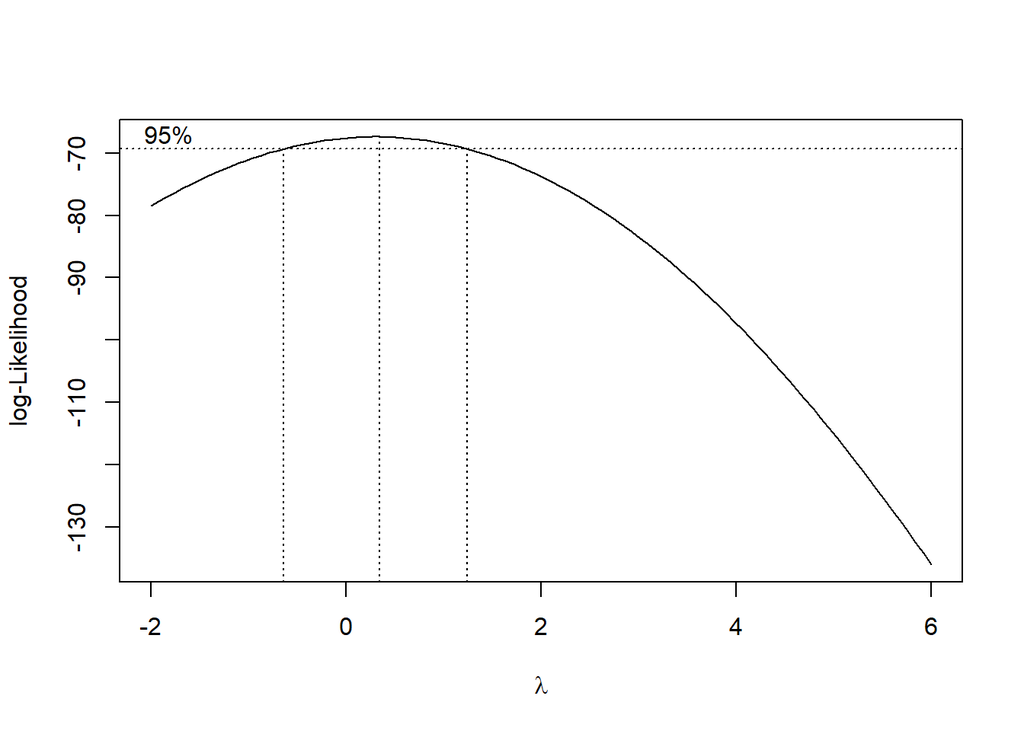

```r
index <- seq(1:90)
bc = boxcox(data1~index, lambda = seq(-2,6,by=1))
```

```r
#Nilai Rounded Lambda
lambda <- bc$x[which.max(bc$y)]
lambda
```

```
## [1] 0.3434343
```

```r
#SK
bc$x[bc$y > max(bc$y) - 1/2 * qchisq(.95,1)]
```

```
##  [1] -0.62626263 -0.54545455 -0.46464646 -0.38383838 -0.30303030 -0.22222222
##  [7] -0.14141414 -0.06060606  0.02020202  0.10101010  0.18181818  0.26262626
## [13]  0.34343434  0.42424242  0.50505051  0.58585859  0.66666667  0.74747475
## [19]  0.82828283  0.90909091  0.98989899  1.07070707  1.15151515  1.23232323
```

Gambar di atas menunjukkan nilai *rounded value* ($\lambda$) optimum sebesar **0.34** dan pada selang kepercayaan 95% nilai memiliki batas bawah **-0.63** dan batas atas **1.23**. Selang tersebut memuat nilai 1 sehingga dapat dikatakan bahwa data stasioner dalam ragam.

Dengan demikian, data stasioner dalam ragam tetapi tidak stasioner dalam rataan.

## Data Partisi 2

```r
data2 <- data.ts[91:295] |> ts()
mean(data2)
```

```
## [1] 32469.27
```

```r
var(data2)
```

```
## [1] 63038095
```

### Plot Time Series

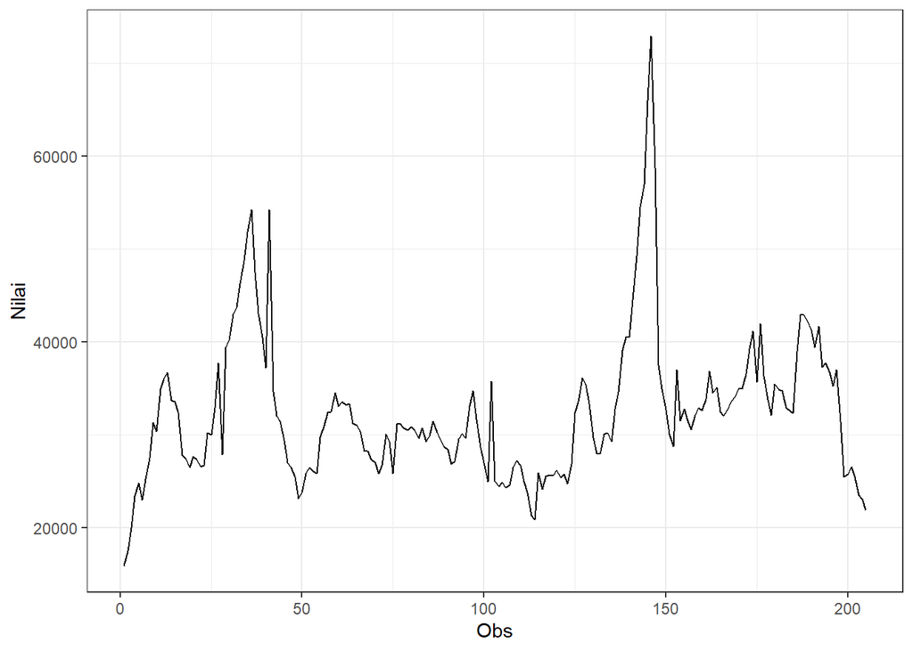

```r
data2 |> as_tsibble() |>
  ggplot(aes(x = index, y = value)) +
  geom_line() + theme_bw() +
  xlab("Obs") + ylab("Nilai")
```

### Plot ACF

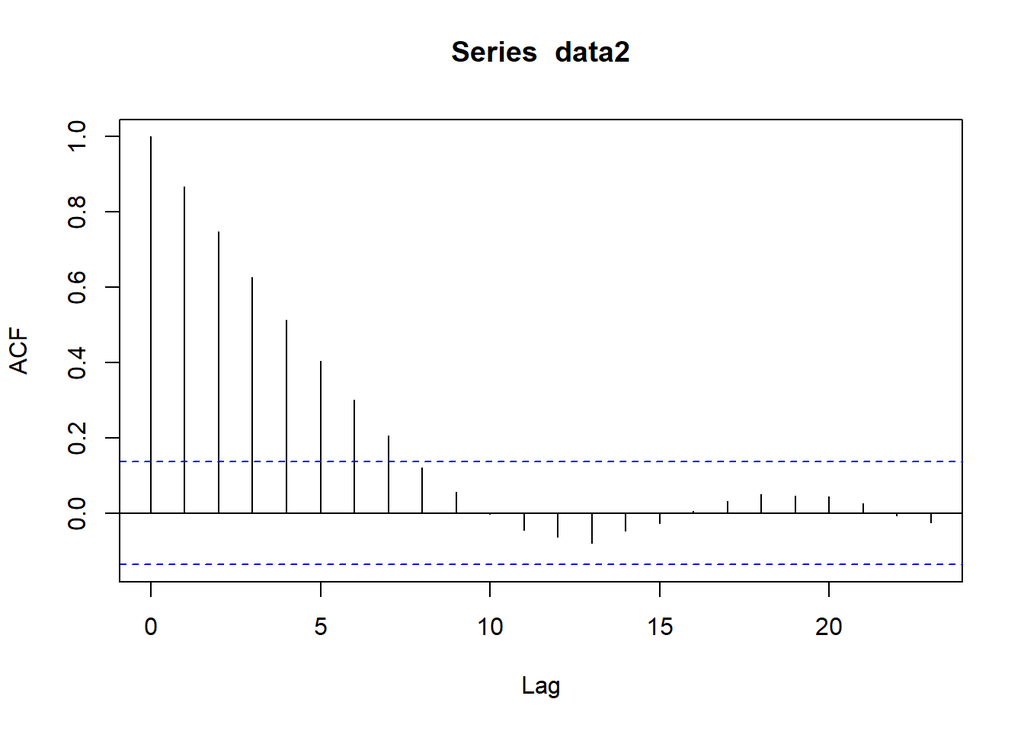

```r
acf(data2)
```

Berdasarkan plot ACF, terlihat bahwa plot ACF pada data tersebut cenderung *tails off* secara lambat dan membentuk gelombang sinus.

### Uji ADF

```r
tseries::adf.test(data2)
```

```
##
##  Augmented Dickey-Fuller Test
##
## data:  data2
## Dickey-Fuller = -3.8348, Lag order = 5, p-value = 0.01844
## alternative hypothesis: stationary
```

$H_0$ : Data tidak stasioner dalam rataan

$H_1$ : Data stasioner dalam rataan

Berdasarkan uji ADF tersebut, didapat *p-value* sebesar 0.0184 yang lebih kecil dari taraf nyata 5% sehingga tolak $H_0$ dan menandakan bahwa data stasioner dalam rataan. Hal ini sesuai dengan hasil eksplorasi menggunakan plot time series dan plot ACF.

### Plot Box-Cox

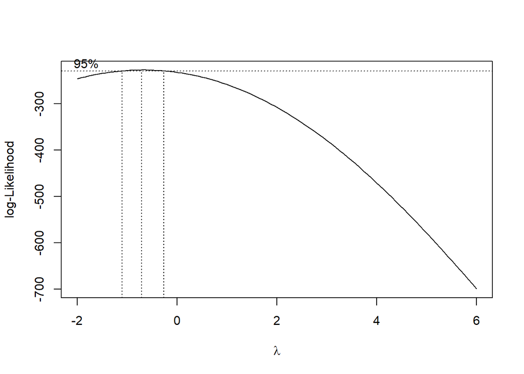

```r
index <- seq(91:295)
bc = boxcox(data2~index, lambda = seq(-2,6,by=1))
```

```r
#Nilai Rounded Lambda
lambda <- bc$x[which.max(bc$y)]
lambda
```

```
## [1] -0.7070707
```

```r
#SK
bc$x[bc$y > max(bc$y) - 1/2 * qchisq(.95,1)]
```

```
##  [1] -1.0303030 -0.9494949 -0.8686869 -0.7878788 -0.7070707 -0.6262626
##  [7] -0.5454545 -0.4646465 -0.3838384 -0.3030303
```

Gambar di atas menunjukkan nilai *rounded value* ($\lambda$) optimum sebesar **-0.71** dan pada selang kepercayaan 95% nilai memiliki batas bawah **-1.03** dan batas atas **-0.30**. Selang tersebut tidak memuat nilai 1 sehingga dapat dikatakan bahwa data tidak stasioner dalam ragam.

Dengan demikian, data stasioner dalam rataan tetapi tidak stasioner dalam ragam.